# Predicting Round Outcomes in Tom Clancy’s Rainbow Six Siege

2023-10-19

Mario Tapia-Pacheco

- Introduction
- Data Pre-processing
- Exploratory Data Analysis
- Fitting Models
  - Logistic Regression
  - K-Nearest Neighbors
  - Random Forest
  - Support Vector Machines
- Choosing Best Model Based on Training Data

## Introduction

The aim of this project is to build a machine learning model to predict the outcome of a round from the video game Tom Clancy’s Rainbow Six Siege. Tom Clancy’s Rainbow Six Siege is a competitive, tactical first-person shooter in which two teams play against each other in objective-based game modes. Each team consists of five players who choose operators with unique abilities and both teams take turns defending and attacking an objective. This project will be trying several different machine learning algorithms to find the best performing model on this binary classification problem.

[figure not shown]

The data set I will be using contains an observation for every player in every round played in Tom Clancy’s Rainbow Six Siege over the course of 3 months. I found the data set on Kaggle. The data were originally shared by Ubisoft in 2020, the game’s publisher, but were removed from the website because it is quite outdated. The link to the Kaggle data set is provided [here](https://www.kaggle.com/datasets/maxcobra/rainbow-six-siege-s5-ranked-dataset).

#### Disclaimer

The data set contains roughly 88 million observations and is split into 22 csv files. However, I will be reducing the number to 5,000 observations in order to save memory.

## Data Pre-processing

```r
library(tidyverse)
library(tidymodels)
library(dplyr)
library(ggplot2)
library(corrplot)
library(kknn)
library(glmnet)
library(naniar)
library(discrim)
library(ranger)
library(randomForest)
library(xgboost)
library(MASS)
library(kernlab)
library(vip)
library(caret)
library(e1071)
tidymodels_prefer()
```

We can start by checking for any missing values and dealing with them accordingly.

```r
data <- read.csv('../data/rainbow_data.csv')
```

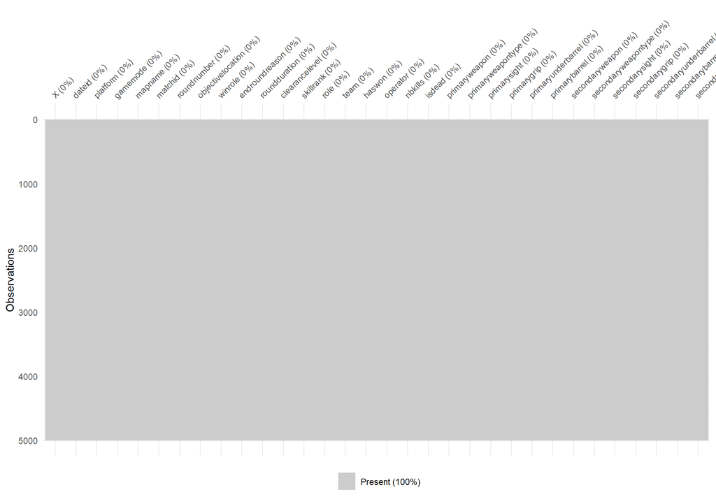

```r
vis_miss(data)
```

Luckily, there are no missing data so I can proceed with the pre-processing. I do not plan to use weapon attachment information so I will drop all those columns.

```r
data1 <- data[-c(1,2,6,20:32)]
```

## Exploratory Data Analysis

```r
data2 <- data1
data2$skillrank <- factor(data2$skillrank,
                          levels = c('Unranked', 'Copper', 'Bronze',
                                     'Silver', 'Gold', 'Platinum', 'Diamond'))

data1$skillrank <- factor(data1$skillrank,
                          levels = c('Unranked', 'Copper', 'Bronze',
                                     'Silver', 'Gold', 'Platinum', 'Diamond'))

data1$haswon <- factor(data1$haswon, levels = c(0, 1))
```

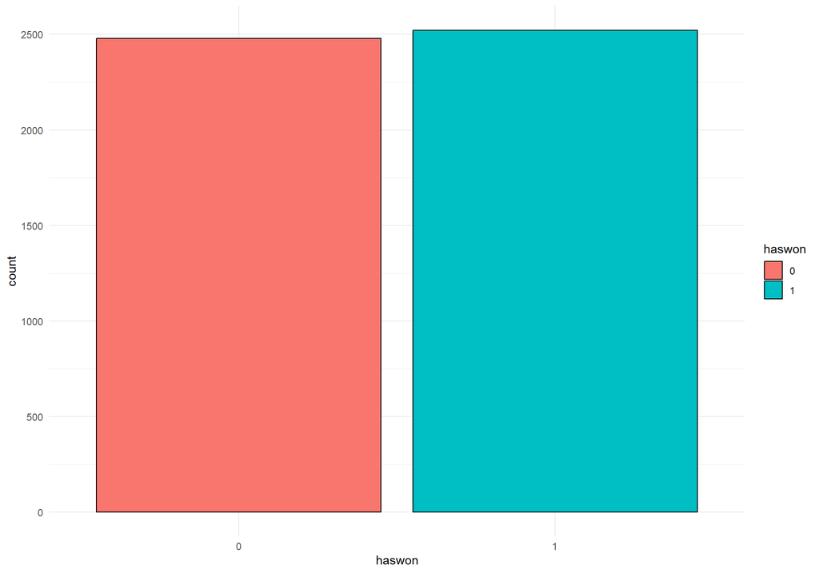

```r
has_won_no <- data1 %>%
  filter(haswon == 0) %>%
  summarise(count = n())

has_won_yes <- data1 %>%
  filter(haswon == 1) %>%
  summarize(count = n())

has_won_counts <- bind_rows(has_won_yes, has_won_no) %>%
  tibble() %>% mutate(has_won_ = c("Yes", "No")) %>%
  select(has_won_, count)

data1 %>%
  ggplot() +
  geom_bar(aes(x = haswon, fill = haswon), color = "black") +
  theme_minimal()
```

There are 2478 haswon = 0 (lost) and 2522 haswon = 1 (won). The observations for each are balanced.

Let’s take a closer look at the data.

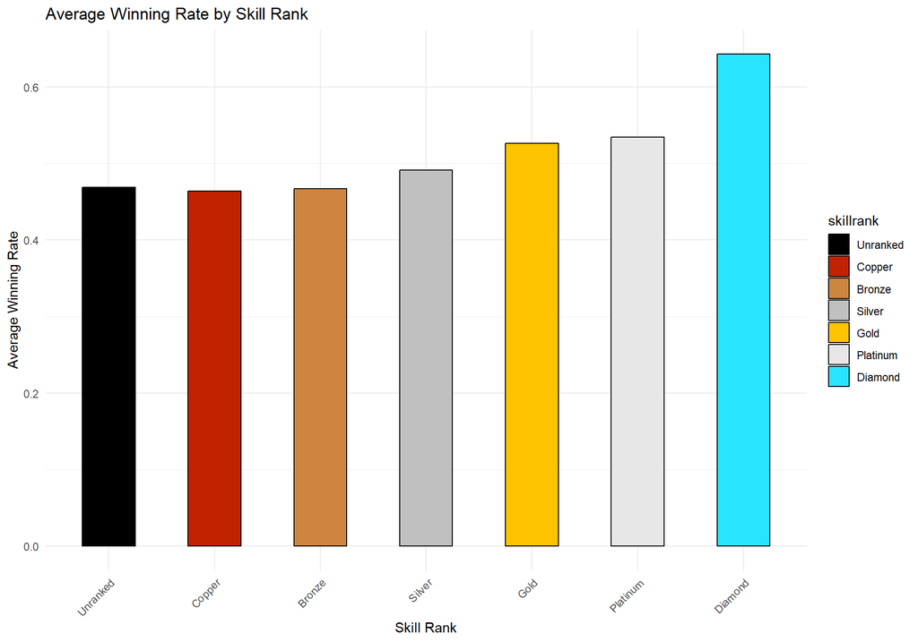

```r
# get avg has won by rank
win_avg_rank <- data2 %>%
  select(skillrank, haswon) %>%
  group_by(skillrank) %>%
  summarise(winning_avg = mean(haswon)) # Calculate mean of haswon per skillrank

rank_colors <- c("Gold" = "#FFC300", "Silver" = "#C0C0C0", "Bronze" = "peru",
                 "Platinum" = "#E7E7E7", "Unranked" = "Black",
                 "Copper" = "#C12200", "Diamond" = "#28E4FF")

# create bar plot
ggplot(win_avg_rank, aes(x = skillrank, y = winning_avg, fill = skillrank)) +
  geom_bar(stat = "identity", width = 0.5, color = "black") +
  scale_fill_manual(values = rank_colors) +
  labs(title = "Average Winning Rate by Skill Rank", x = "Skill Rank", y = "Average Winning Rate") +
  theme_minimal() +
  theme(axis.text.x = element_text(angle = 45, hjust = 1))
```

```r
# there seems to be a positive correlation here with rank and winning avg
```

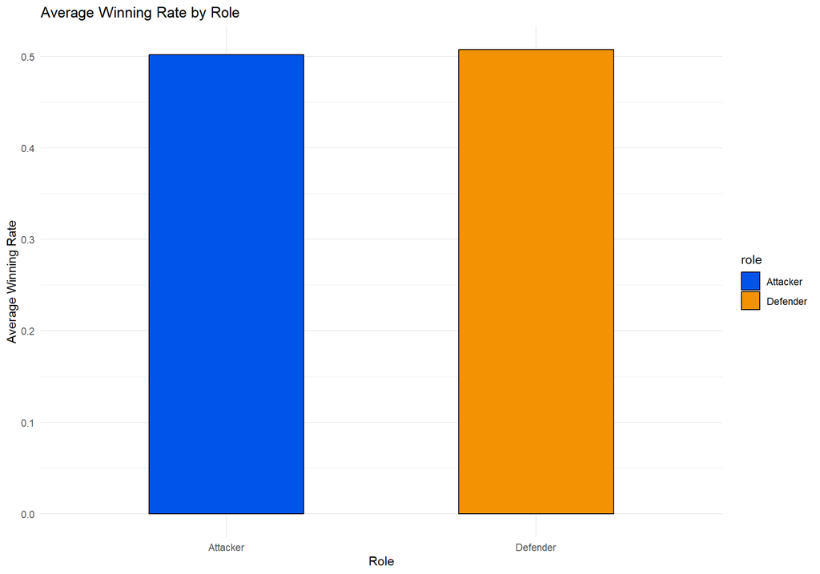

```r
# get avg haswon by role
win_avg_role <- data2 %>%
  select(role, haswon) %>%
  group_by(role) %>%
  summarise(winning_avg = mean(haswon))

role_col <- c("Attacker" = "#0054E9", "Defender" = "#F39303")

# create bar plot
ggplot(win_avg_role, aes(x = role, y = winning_avg, fill = role)) +
  geom_bar(stat = "identity", width = 0.5, color = "black") +
  scale_fill_manual(values = role_col) +
  labs(title = "Average Winning Rate by Role", x = "Role", y = "Average Winning Rate") +
  theme_minimal()
```